# Module 4: ARMA Modeling, Box-Jenkins, and Model Selection

Econ 6376 — Applied Time Series Econometrics

## How to Use These Notes

This chapter has one main reading path and three optional layers.

- **Core** material is the main text. It contains the concepts, notation, interpretations, and applied skills expected of everyone.
- **Deeper Dive** sections explain why a result works or develop it more fully. They are useful, but they can be skipped on a first reading.
- **Technical Note** sections state qualifications or formal details that matter for precise reasoning.
- **Looking Ahead** sections introduce an idea that will be taught formally in a later module.

If you missed lecture, read the main text, run the Core code, and complete the Core Practice problems. Then return to the optional sections that address your questions or interests.

## Core Learning Objectives

By the end of this module, you should be able to:

1. State the ARMA(p,q) correlogram trap — both ACF and PACF tail off — and explain why Module 3’s identification rules alone cannot recover $(p, q)$.
2. Describe the **Box-Jenkins methodology** (Identification $\rightarrow$ Estimation $\rightarrow$ Diagnostic checking $\rightarrow$ Forecasting) as a reusable workflow and locate where Modules 3, 4, and 5 sit inside it (Box & Jenkins, 1970).
3. Explain in plain language what a **likelihood function** is and why we use **maximum likelihood estimation** for ARMA models under a Gaussian innovation assumption. Distinguish conditional from exact likelihood at the name level. State the conditional ML / CSS $\approx$ OLS-like relationship for pure AR(p) and note that exact ML/default `arima()` is usually numerical.
4. Write down the classical likelihood-based information-criterion structure $-2 \log L + \text{penalty}$, and state the specific penalties for **AIC** (Akaike, 1974), **BIC/SBC** (Schwarz, 1978), and **AICc** (Hurvich & Tsai, 1989). Identify which penalty is harsher for realistic sample sizes.
5. Compare AIC and BIC on two axes: the motivational story (KL divergence vs. Bayesian posterior) and the asymptotic property (efficient-for-forecasting vs. consistent-for-selection). Choose an IC **a priori** based on the modeling goal: BIC for explanation/parsimony, AIC for prediction/forecasting. Articulate the “AIC overfits, BIC underfits” pattern and why their disagreement is informative.
6. Fit candidate ARMA models in R using `stats::arima()` and `forecast::Arima()`, compare them on AIC/BIC/AICc, and contrast manual selection with `forecast::auto.arima()`.
7. Run a model-selection Monte Carlo: generate 500 ARMA(1,1) realizations, fit ARMA(p,q) for a grid of orders, and tabulate how often AIC vs. BIC selects the true model. Interpret the results as evidence that IC is a tool with limits.
8. Apply the full workflow to a real macro series (differenced FRED UNRATE): propose candidate orders, compare IC, pick a working model, and articulate why a definitive choice still requires the residual diagnostics coming in Module 5.
9. Identify the three open questions Module 4 leaves hanging — residual behavior, seasonality, and forecasting performance — and map them to the remaining Block 3 and Block 4 lectures.

## 4.1 The Correlogram Trap and the Model Selection Problem

### 4.1.1 Where We Stopped in Module 3

Module 3 ended with a powerful tool: the ACF/PACF identification table.

| Process | ACF | PACF |
| --- | --- | --- |
| **AR(p)** | Tails off | **Cuts off at lag $p$** |
| **MA(q)** | **Cuts off at lag $q$** | Tails off |
| **ARMA(p,q)** | Tails off | Tails off |

For pure AR and pure MA processes, the fingerprint is decisive. A sharp PACF cutoff at lag 2 says AR(2). A sharp ACF cutoff at lag 1 says MA(1). These rules are clean, reliable, and testable in the simulation gallery. But look at the third row. For ARMA(p,q), both correlograms tail off. The fingerprint tells you the *class* — “this is probably an ARMA” — but it cannot tell you the *orders*. Six students can look at the same ARMA(1,1) correlogram and propose six different models, and none of them would be obviously wrong from the correlogram alone.

This is the correlogram trap. It is not a failure of the identification rules; it is the boundary of what those rules were designed to do. And it is the problem that motivates everything in this module.

One thing has *not* changed since last module: the mixing board. Every non-seasonal slider on the master equation was already turned on by the end of Module 3. Today is about how we *choose the settings*, not about which sliders exist — we restate the board in §4.2.3.

### 4.1.2 The Trap in Action

Recall the ARMA(1,1) from the Module 3 simulation gallery ($\phi = 0.6, \theta = 0.4$). We can regenerate it using the `arma_simulator()` function built in Module 3 — per the course convention, from Module 4 onward we `source()` it from its canonical home in `helpers/simulators.R` instead of re-defining it:

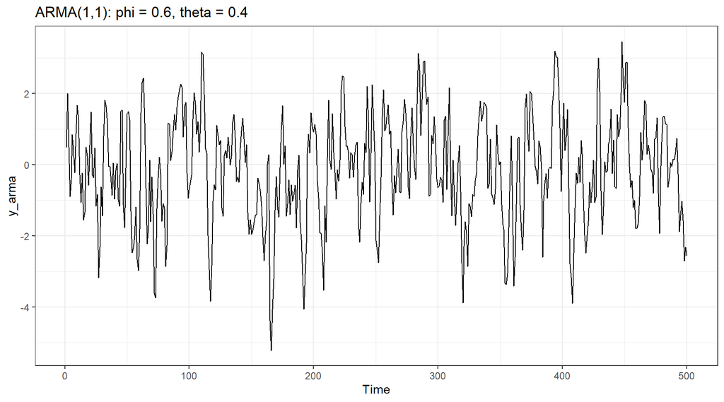

```r
library(forecast); library(ggplot2); library(patchwork)
source("../helpers/simulators.R")   # arma_simulator(), built live in Module 3

set.seed(1985)
y_arma <- arma_simulator(n = 500, phi = 0.6, theta = 0.4)

autoplot(y_arma) + ggtitle("ARMA(1,1): phi = 0.6, theta = 0.4") + theme_bw()
```

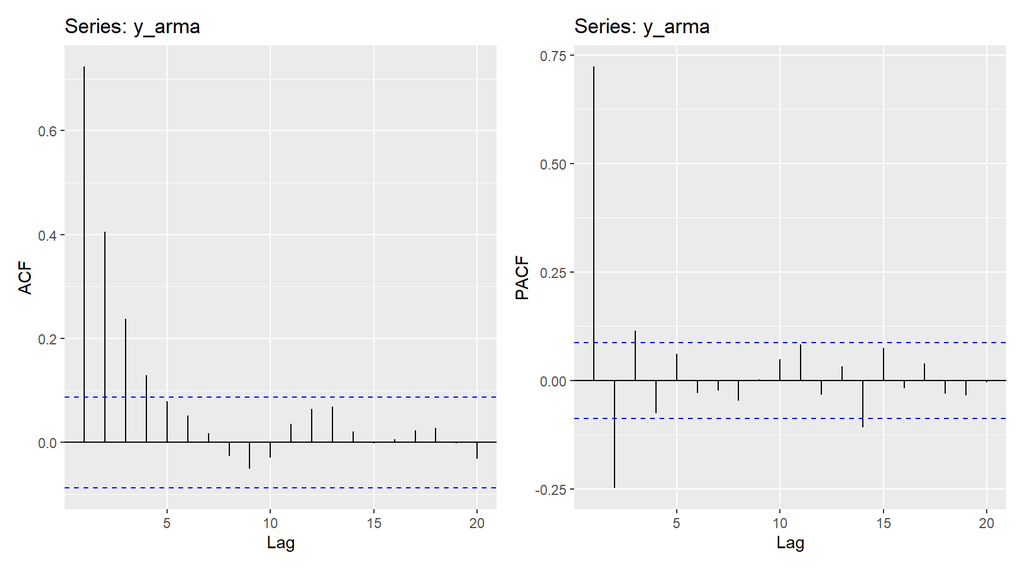

```r
(ggAcf(y_arma, lag.max = 20) | ggPacf(y_arma, lag.max = 20))
```

Look at the two correlograms. The ACF decays — it tails off, with no sharp cutoff. The PACF also tails off, with no clean cutoff at any particular lag. If you were forced to read these as a fingerprint, you might call it AR(1), or MA(1), or ARMA(1,1), or maybe AR(2). All four guesses are defensible from the picture alone, and the data came from a DGP *we wrote ourselves*. On real data, where the DGP is unknown and the sample correlograms are noisier, the ambiguity is worse.

### 4.1.3 Three Possible Answers to “Which Order?”

The rest of the module fills the gap with three tools, introduced in order:

1. **Judgment from correlograms alone.** This is Module 3’s tool. Works for pure AR or MA. Fails for ARMA. Good starting point, bad final answer.
2. **Information criteria.** Fit several candidates, score each with a rule that rewards fit and punishes complexity, pick the best score. This is the new tool for Module 4.
3. **Residual diagnostics.** After you fit, check whether the residuals look like white noise — if they do not, your model is misspecified. This is the new tool for Module 5. Preview only today.

We will use (1) to generate candidates, (2) to score them, and (3) *next module* to confirm the winner. That three-step loop is the core of the Box-Jenkins methodology, which we meet in Section 4.2.

### 4.1.4 Why Not Just Use $R^2$?

A natural question from anyone trained in cross-sectional regression: why not pick the model with the highest $R^2$? Because adding parameters always weakly increases $R^2$, and for a flexible family like ARMA you can drive $R^2$ arbitrarily high by piling on lags. $R^2$ has no complexity penalty and is not a model-selection tool — it is a descriptive statistic.

What about adjusted $R^2$? It does adjust for degrees of freedom, but it was designed for linear-regression summaries, not for comparing likelihood-based ARMA specifications. It does not carry the KL-risk motivation of AIC or the model-selection motivation of BIC, and it is not the score reported by the ARMA workflow we use. **Friends do not let friends rank ARMA candidates by adjusted $R^2$ when AIC, AICc, BIC, diagnostics, and out-of-sample evaluation are available.**

We need a scoring rule that builds a principled fit-versus-complexity trade-off into its structure. That is what AIC and BIC do.

## 4.2 The Box-Jenkins Methodology

### 4.2.1 The Four-Step Workflow

The most influential framework for time series modeling is the **Box-Jenkins methodology**, introduced in Box and Jenkins (1970) and still the organizing template for applied work more than fifty years later. It has four steps:

1. **Identification** — propose candidate orders $(p, d, q)$ from visual evidence. This step uses Module 2 (order of integration $d$, from the ADF and KPSS tests) and Module 3 (ACF/PACF for $p$ and $q$). The goal is to narrow the candidate set from infinite to a manageable handful.
2. **Estimation** — fit each candidate by maximum likelihood. Obtain parameter estimates, standard errors, and a log-likelihood. This is Section 4.3.
3. **Diagnostic checking** — verify the fit. Are the residuals white noise? Do the parameters look sensible? Are the roots of $\hat{\Phi}(L)$ and $\hat{\Theta}(L)$ safely outside the unit circle? This is Module 5 territory.
4. **Forecasting** — once a model passes diagnostics, use it for prediction. This is Block 4.

Today’s module covers Step 2 in full, adds **information criteria** as the intermediate scoring step between Steps 2 and 3, and previews Step 3 just enough to set up Module 5.

### 4.2.2 Why It Is a Procedure, Not a Pick

Read those four steps as a procedure rather than as a description. Each one hands something specific to the next, and the reason for running all four in order is that the model you end up with is then the output of a stated process instead of a judgment call about which specification looked right.

1. **Identification produces a set, not a favorite.** The order of integration from Module 2 and the correlograms from Module 3 give you the class and a plausible range of orders. They do not rank anything.
2. **The candidate set is written down before anything is fitted.** Three or four $(p, q)$ pairs, fixed in advance, so that the comparison runs over a stated set rather than over whatever you happened to try until something looked good.
3. **Every candidate is fitted, and every candidate is scored on the same terms.** An order you did not fit has no log-likelihood and therefore no score, so it never enters the comparison.
4. **The winner is checked before it is used.** A best score is the best entry in the set you wrote down. It is not a statement that the model fits.

Skipping a step breaks something specific. The common version is going from an ACF plot straight to `auto.arima()` and reporting whatever comes back: the candidate set was never stated, so nothing is known about what the winner beat, and the residuals were never inspected, so nothing is known about whether it fits. A ranking gets reported as a finished model.

### 4.2.3 Mapping the Course onto Box-Jenkins

It is worth seeing explicitly where each lecture sits in the workflow:

| Box-Jenkins Step | Course Location |
| --- | --- |
| **1. Identification** | Module 2 ($d$), Module 3 ($p, q$ from ACF/PACF) |
| **2. Estimation** | **Module 4** (MLE, this module) |
| **IC scoring** (between 2 and 3) | **Module 4** (AIC, BIC, AICc) |
| **3. Diagnostic checking** | Module 5 (residual diagnostics, Ljung-Box, seasonality) |
| **4. Forecasting** | Block 4 |

Reproduce the master equation from Modules 1 and 3 one more time:

$$y_t = \alpha + \delta t + \sum_{j=1}^{p} \phi_j y_{t-j} + \sum_{l=1}^{q} \theta_l \epsilon_{t-l} + \epsilon_t$$

All of the non-seasonal terms are now on and *fittable*. The seasonal block is still off — that is Module 5’s job. What changes in this module is not which knobs are available on the mixing board, but *how we pick the settings*. Module 3 wrote down the DGP. Module 4 fits it.

## 4.3 Maximum Likelihood for ARMA — Concept Only

### 4.3.1 What Is a Likelihood?

**Plain-language definition.** The likelihood is the probability of seeing the data you saw, *treated as a function of the parameters*. It asks: “Given these particular parameter values, how surprising is it that I got this exact data set?” Bigger likelihood means less surprising means the parameters fit the data well.

**The hindsight framing.** Likelihood is the frequentist’s version of hindsight. You already saw the data. Now ask, “which parameter values would have made this the most likely thing to happen?” Those are the maximum likelihood estimates.

**Likelihood freezes the data and moves the parameters.** The data you observed stay exactly where they are — nothing about them is being redrawn or reimagined. What moves is the parameter vector. You walk through candidate parameter values and, at each one, ask how much density the model places at the data you already have. The parameter values that place the most density there are the maximum likelihood estimates.

### 4.3.2 The Gaussian ARMA Log-Likelihood — Stated, Not Derived

For an ARMA(p,q) with Gaussian innovations $\epsilon_t \sim N(0, \sigma^2)$, the (exact) likelihood of observing $y_1, y_2, \ldots, y_T$ as a function of the parameter vector $\boldsymbol{\vartheta} = (\alpha, \phi_1, \ldots, \phi_p, \theta_1, \ldots, \theta_q, \sigma^2)$ is:

$$L(\boldsymbol{\vartheta} \mid y_1, \ldots, y_T) = f(y_1, \ldots, y_T \mid \boldsymbol{\vartheta})$$

where $f$ is the joint density of the observations under the model. We take logs for two reasons: products become sums, and the numerical range becomes manageable. The **log-likelihood** is:

$$\ell(\boldsymbol{\vartheta}) = \log L(\boldsymbol{\vartheta} \mid y_1, \ldots, y_T)$$

The **maximum likelihood estimate** is:

$$\hat{\boldsymbol{\vartheta}}_{\text{MLE}} = \arg\max_{\boldsymbol{\vartheta}} \; \ell(\boldsymbol{\vartheta})$$

That is the entire statement. We do not derive the closed form — it does not have one for general ARMA, and that is *why* we hand the problem to a numerical optimizer.

**Two flavors, both names only:**

- **Exact (unconditional) likelihood**: uses the full joint density of all $T$ observations including the initial values. More accurate, more expensive. This is what `arima()` calls `method = "ML"`.
- **Conditional likelihood**: conditions on the first few observations (or on $\epsilon_0 = 0$) and computes the density of the remaining observations. Much cheaper, slightly biased for small samples. Related to conditional sum of squares (CSS). The default `method = "CSS-ML"` in `arima()` initializes with CSS and polishes with ML.

When you see `method = "CSS-ML"` in an `arima()` call, that is what it means. For the homework and for this course, always use the default unless you have a reason not to.

### 4.3.3 Conditional MLE / CSS $\approx$ OLS for Pure AR Models

This is the bridge between the regression world you already know and the likelihood world we are entering.

**Claim.** For a pure AR(p) with Gaussian innovations, the conditional MLE / CSS fit (conditioning on $y_1, \ldots, y_p$) is OLS-like: it gives the same coefficient estimates as OLS under the usual setup, so the AR(p) fit can be read like a regression.

$$y_t = \alpha + \phi_1 y_{t-1} + \ldots + \phi_p y_{t-p} + \epsilon_t, \qquad t = p+1, \ldots, T.$$

**Intuition, not proof.** When the innovations are Gaussian, maximizing the likelihood is equivalent to minimizing the sum of squared errors of the one-step-ahead predictions. For a pure AR, those one-step-ahead predictions are linear in past $y$’s with no unobserved quantities, so the conditional likelihood and CSS objective collapse to the same least-squares problem you solve with OLS. For MA or ARMA models, the one-step-ahead prediction depends on past *innovations*, which are unobserved and must be recursively reconstructed — that is what breaks the OLS equivalence and forces the numerical optimizer.

**Live verification.** Simulate an AR(1) and fit it both ways:

```r
set.seed(1985)
y <- arma_simulator(n = 500, phi = 0.6)

fit_css <- arima(y, order = c(1, 0, 0), include.mean = FALSE, method = "CSS")
fit_ols <- lm(y[-1] ~ y[-length(y)] - 1)

coef(fit_css)["ar1"]     # approx 0.6
```

```
      ar1
0.5573313
```

```r
coef(fit_ols)            # approx 0.6 — same number
```

```
y[-length(y)]
    0.5573313
```

The coefficients agree to every printed digit. That is the conditional AR fit behaving like OLS. The default `arima()` fit adds the exact-ML polish, which is why the right classroom phrase here is “OLS-like” rather than “literally OLS.” For MA or ARMA, MLE is genuinely new — because the past errors $\epsilon_{t-1}, \epsilon_{t-2}, \ldots$ are not observable and the optimizer has to reconstruct them as it goes.

#### Deeper Dive — A Two-Point Log-Likelihood by Hand

The briefest possible numerical moment, to demystify what `log likelihood = -234.1` means in an `arima()` printout.

Take an AR(1) with $\phi = 0.6$, $\sigma^2 = 1$, and two observations $y_1 = 1.0$, $y_2 = 0.8$. Under the model, $y_2 \mid y_1 \sim N(\phi y_1, \sigma^2) = N(0.6, 1)$, so:

$$\log f(y_2 \mid y_1; \phi = 0.6) = -\tfrac{1}{2}\log(2\pi) - \tfrac{1}{2}(0.8 - 0.6)^2 = -0.9189 - 0.02 = -0.939.$$

Now try $\phi = 0.9$: the conditional mean becomes $0.9$, and the log density becomes $-0.9189 - \tfrac{1}{2}(0.8 - 0.9)^2 = -0.924$. Slightly higher. **That is MLE on two points — walk the parameter, watch the log density move, pick the top.** Scale that up to 500 points and a multi-dimensional $\boldsymbol{\vartheta}$ and you have the optimization problem `arima()` is solving.

The `log likelihood` in an `arima()` printout is just a sum of $T$ log densities like the ones above. It is not mysterious; it is arithmetic.

### 4.3.4 Reading an `arima()` Printout

Fit a model on the simulated ARMA(1,1) from Section 4.1 and walk through every field in the output:

```r
fit <- arima(y_arma, order = c(1, 0, 1))
fit
```

```
Call:
arima(x = y_arma, order = c(1, 0, 1))

Coefficients:
         ar1     ma1  intercept
      0.5349  0.4287    -0.1538
s.e.  0.0503  0.0573     0.1356

sigma^2 estimated as 0.9791:  log likelihood = -704.67,  aic = 1417.33
```

The printout shows:

- **Parameter estimates** ($\hat{\phi}_1$, $\hat{\theta}_1$, and the printed `intercept`) — these are the MLE values of the parameters under R’s convention.
- **Standard errors** — these come from the curvature (Hessian) of the log-likelihood at its maximum. We will not derive that, but that is where they come from.
- **`sigma^2`** — the estimated innovation variance $\hat{\sigma}^2$.
- **`log likelihood`** — the value $\ell(\hat{\boldsymbol{\vartheta}})$ from Section 4.3.2. This is the sum of all the log densities evaluated at the MLE.
- **`aic`** — the Akaike Information Criterion, which is the next topic.

Remember our notation convention: $\epsilon_t$ is the true DGP innovation; $e_t = y_t - \hat{y}_t$ is the residual from an estimated model. The `sigma^2` in the printout estimates $\text{Var}(\epsilon_t)$, but the residuals you extract with `residuals(fit)` are $e_t$, not $\epsilon_t$.

**R convention to memorize.** For an undifferenced stationary ARMA fit, `stats::arima()` and `forecast::Arima()` label the estimated **process mean** $\hat{\mu}$ as `intercept`. It is not the intercept $\hat{\alpha}$ in the course’s recursive estimating equation. R parameterizes the fitted model as

$$y_t - \hat{\mu} = \sum_{j=1}^{p}\hat{\phi}_j(y_{t-j}-\hat{\mu}) + \sum_{l=1}^{q}\hat{\theta}_l e_{t-l} + e_t.$$

Expanding it gives the translation

$$\hat{\alpha} = \hat{\mu}\left(1-\sum_{j=1}^{p}\hat{\phi}_j\right).$$

So report the printed coefficient as $\hat{\mu}$, and convert it before placing it into the master-equation recursion. For a zero-mean DGP, use `include.mean = FALSE` explicitly rather than relying on a default.

## 4.4 Information Criteria

### 4.4.1 The Generic Structure: Fit Minus Penalty

The generic structure of the **classical likelihood-based criteria used in Core** is:

$$\text{IC} = -2 \log L(\hat{\boldsymbol{\vartheta}}) + \text{penalty}(k, T)$$

where $k$ is the number of estimated parameters (including $\sigma^2$ and, if present, R’s process-mean term) and $T$ is the sample size.

Read it piece by piece:

- $-2 \log L$ is the **deviance**. Bigger log-likelihood $=$ smaller deviance $=$ better fit. The $-2$ factor is a historical convention that makes the deviance behave like a chi-square under certain asymptotics.
- The **penalty** punishes complexity. Without it, you could always drive $-2 \log L$ down by adding parameters — every extra parameter weakly increases the maximized likelihood. The penalty is what stops the arms race.
- **Smaller IC is better.** You add a model to the scoreboard and keep the one with the lowest number.

**The Olympic all-around analogy.** Think of IC scoring like gymnastics. You get points for your routine (log-likelihood, the fit component) and then a difficulty tariff is applied (penalty, the complexity component). A simple routine done perfectly can beat a difficult routine done sloppily. The whole scoring system exists because otherwise gymnasts would all attempt triple twisting double backflips and fall on their faces — and every ARMA modeler would fit ARMA(10,10) on 200 data points.

### 4.4.2 AIC, BIC, and AICc

Three penalties, three stories.

**AIC** (Akaike, 1974):

$$\text{AIC} = -2 \log L + 2k$$

The penalty is $2$ per parameter, regardless of the sample size. Akaike motivated AIC (intuitively) by minimizing Kullback-Leibler divergence between the fitted model and the (unknown) true DGP — “how wrong, on average, is the model as a description of nature?” AIC does not ask whether the true model is in the candidate set; it asks which candidate is the least wrong approximation. This is the philosophical underpinning for why AIC tends to prefer slightly larger models: a slightly-too-large model is a better approximation than a slightly-too-small one, even if the extra parameters are not “truly” present.

**BIC (or SBC)** (Schwarz, 1978):

$$\text{BIC} = -2 \log L + k \log T$$

The penalty is $\log T$ per parameter. Schwarz motivated BIC (intuitively) by a Bayesian approximation to the marginal likelihood — “how well does this model explain the data under a prior over parameters?” The penalty is heavier than AIC for any $T \geq 8$ (since $\log 8 \approx 2.08 > 2$), and it gets heavier as $T$ grows. This makes BIC more aggressive at eliminating extra parameters.

**AICc** (Hurvich & Tsai, 1989):

$$\text{AICc} = -2 \log L + 2k + \frac{2k(k+1)}{T - k - 1}$$

The extra term $2k(k+1)/(T - k - 1)$ vanishes as $T \to \infty$, so AICc and AIC agree in large samples. In small samples, AICc penalizes extra parameters more heavily than AIC, which helps prevent AIC’s well-known overfitting tendency in short series. **Rule of thumb**: use AICc whenever $T / k < 40$.

**A numerical moment.** Suppose we have $T = 200$ and we are comparing a model with $k = 3$ parameters to a model with $k = 5$. The BIC penalty increases by $2 \log 200 \approx 10.6$ when we add two parameters. The AIC penalty increases by $2 \times 2 = 4$. So AIC is happy to add parameters that improve $-2 \log L$ by more than 4; BIC needs the improvement to exceed 10.6. BIC is the tougher grader.

### 4.4.3 AIC vs. BIC: Two Asymptotic Properties, One Judgment Call

This is the question students ask about most, and it deserves an honest answer rather than a slogan.

**Two different questions, two different answers:**

| Property | AIC | BIC |
| --- | --- | --- |
| Motivating criterion | KL divergence from truth | Bayesian posterior / marginal likelihood |
| Penalty weight | $2$ per parameter | $\log T$ per parameter |
| Asymptotic property | **Efficient** for forecasting | **Consistent** for selection |
| Finite-sample tendency | **Overfits** — picks too large a model | **Underfits** — picks too small a model |
| When to prefer | Forecasting, prediction, dense DGPs | Parsimony, sparse DGPs, identifying the “true” model |

What “efficient” and “consistent” mean here:

- **AIC is efficient** in the sense that, among all candidate models, the AIC-selected model converges to the one with the smallest expected out-of-sample forecast error. AIC’s working assumption is “all models are wrong, but some are useful; pick the one that will be least wrong on average when forecasting.” AIC also has a deep connection to leave-one-out cross-validation — asymptotically, minimizing AIC is equivalent to minimizing the cross-validated prediction error.
- **BIC is consistent** in the sense that, if the true model is in the candidate set, the probability that BIC selects it goes to 1 as $T \to \infty$. BIC’s working assumption is “the true model is in my set; tell me which one it is.” BIC works well when the DGP is genuinely sparse and you want to recover a parsimonious description.

#### Technical Note — What the Asymptotic Labels Promise

These are conditional theorems, not software warranties. AIC’s predictive-efficiency results and BIC’s selection-consistency results require standard likelihood regularity and appropriate candidate-set conditions; BIC additionally needs the true finite-dimensional model to be represented in the candidate set. Neither theorem guarantees that the selected model wins on the particular future sample you care about. The applied rule remains AIC/AICc for a prediction-first shortlist and BIC for a parsimony-first shortlist; Block 4 checks actual predictive performance with rolling-origin out-of-sample losses. Hamilton Chapter 5 supplies the likelihood regularity behind the fitting step, and Enders Chapter 2, pp. 79–87, develops forecast evaluation.

### 4.4.4 Pick One A Priori: Explanation vs. Prediction

This is the key practical guidance. You should choose your primary IC **before** fitting, based on your modeling goal — not after, based on which one gives you the answer you prefer.

**If your goal is to explain** — you believe the true DGP is in (or near) your candidate set and you want the most parsimonious description of the data-generating mechanism — **use BIC**. Its consistency property means it will find the true model in the limit, and its heavier penalty keeps you from overparameterizing.

**If your goal is to predict** — you want the model that will forecast best out of sample, and you do not particularly care whether it is “true” — **use AIC (or AICc)**. Its efficiency property means it targets minimum forecast error, and its connection to cross-validation gives it a direct link to the out-of-sample loss you actually care about.

Or, as the in-class mnemonic goes: *AIC likes big models and it cannot lie. BIC thinks flat models are the thing.*

The choice is not about which criterion is “better” — it is about what question you are asking the data. Explanation and prediction are different tasks with different optimal trade-offs between fit and parsimony. Picking one a priori based on your task is the disciplined move; reporting both lets you see how sensitive the choice is.

**The philosopher and the accountant.** AIC is the philosophy professor — “all models are wrong, but some are useful; pick the one that will be least wrong on average when forecasting.” BIC is the accountant — “tell me exactly which model generated this data, assuming you really are in my set.” Both grade the exam; they grade on different scales because they are asking different questions.

**The honest message.** In practice, reporting both is the professional default. When they agree, you have more confidence that the penalty choice is not driving the shortlist. When they disagree, AIC usually picked a bigger model whose extra parameters improved the likelihood enough to clear its prediction-oriented penalty but not BIC’s parsimony-oriented penalty. Whether those terms improve actual forecasts is checked out of sample in Block 4. The disagreement is useful information, not a failure.

#### Technical Note — Which IC Your Software Reports

The textbook and software conventions vary. Enders reports AIC and SBC (= BIC). `stats::arima()` reports AIC by default. `forecast::auto.arima()` uses AICc by default. `forecast::Arima()` reports all three. Students should not panic if different software shows different fields — know what each field is and read it. (The Core field guide in §4.5.1 repeats the parts of this you need for the problem sets.)

#### Looking Ahead — The Alphabet Soup of Information Criteria

AIC, BIC, and AICc are the three you will use in this course — but they are far from the only letters in the soup. Frame this the way you would the government’s three-letter agencies: there are more of them than you think, and each has its own jurisdiction.

| Abbreviation | Full Name | Penalty | One-Liner |
| --- | --- | --- | --- |
| **AIC** | Akaike Information Criterion | $2k$ | KL divergence, the baseline |
| **BIC / SBC** | Bayesian / Schwarz Bayesian IC | $k \log T$ | Bayesian motivation, harsher penalty |
| **AICc** | Corrected AIC | $2k + 2k(k+1)/(T-k-1)$ | Small-sample fix for AIC |
| **HQIC** | Hannan-Quinn IC | $2k \log \log T$ | A hybrid between AIC and BIC |
| **DIC** | Deviance IC | Posterior mean deviance + effective complexity | Bayesian hierarchical-model criterion; not the plug-in classical formula above |
| **WAIC** | Watanabe-Akaike IC | Pointwise predictive fit + effective complexity | Fully Bayesian predictive criterion; not a fixed-$k$ penalty |

**The HQIC form explicitly** (Hannan & Quinn, 1979):

$$\text{HQIC} = -2 \log L + 2k \log \log T$$

The penalty $2 \log \log T$ sits between AIC’s flat $2$ and BIC’s $\log T$ for moderate sample sizes. For $T = 200$, AIC penalizes $2$ per parameter, HQIC penalizes $2 \log \log 200 = 2 \times 1.667 \approx 3.33$, and BIC penalizes $\log 200 \approx 5.30$. HQIC is a compromise grader — not as generous as AIC, not as strict as BIC.

You will encounter HQIC in Block 7 when `vars::VARselect()` reports it alongside AIC, BIC, and a fourth criterion (FPE, the final prediction error) for VAR lag selection. When you see it in that printout, you will know what it is: the same $-2 \log L + \text{penalty}$ structure with yet another penalty.

**The message.** We will use AIC, AICc, and BIC for the rest of this course. AIC, AICc, BIC, and HQIC share the simple maximized-log-likelihood-plus-penalty structure shown here. DIC and WAIC use posterior summaries and an *effective* complexity rather than merely inserting another fixed penalty into that classical formula. The names sound alike; the objects are not interchangeable.

## 4.5 The ARMA Modeling Workflow in R

### 4.5.1 Three Functions, Three Purposes

R gives us three functions for fitting ARMA/ARIMA models, and students often confuse them. Here is the field guide.

**`stats::arima()`** — base R. Fits ARIMA models by MLE (default `method = "CSS-ML"`). Returns parameter estimates, standard errors, log-likelihood, and AIC. Does *not* return AICc or BIC by default. Quiet, no package loads, always available. Use when you want a clean minimal fit.

**`forecast::Arima()`** — Rob Hyndman’s wrapper around `stats::arima()`. Same fitting engine, but (a) returns AIC, AICc, and BIC in one object; (b) handles drift terms more gracefully; (c) plays nicely with the rest of the `forecast` package (e.g., `forecast()`, `checkresiduals()`). **This is the course default** for the rest of Block 3 and Block 4.

**`forecast::auto.arima()`** — the Hyndman-Khandakar algorithm (2008). Searches over $(p, d, q)$ (and seasonal orders if seasonal data is detected) and returns the model that minimizes an IC — **AICc by default**. Options to force BIC (`ic = "bic"`) or AIC (`ic = "aic"`). Also performs unit-root tests (KPSS by default) to pick $d$ automatically. It is fast because it uses a stepwise search rather than a full grid, and it is *mostly* reliable but not perfect.

### 4.5.2 Three-Way Fit Comparison on the Simulated ARMA(1,1)

Return to the simulated ARMA(1,1) from Section 4.1 and fit it three ways:

```r
# The simulated DGP has mean zero, so every comparison uses that policy.
# Manual with stats::arima — minimal output
fit_m <- arima(y_arma, order = c(1, 0, 1), include.mean = FALSE)

# Manual with forecast::Arima — IC fields populated
fit_f <- Arima(y_arma, order = c(1, 0, 1), include.mean = FALSE)

# Automatic — let the algorithm choose p and q under the same zero-mean policy
fit_auto <- auto.arima(y_arma, ic = "aicc", stepwise = TRUE,
                       approximation = FALSE, d = 0, seasonal = FALSE,
                       allowmean = FALSE, allowdrift = FALSE)

summary(fit_f)
```

```
Series: y_arma
ARIMA(1,0,1) with zero mean

Coefficients:
         ar1     ma1
      0.5398  0.4265
s.e.  0.0501  0.0574

sigma^2 = 0.9855:  log likelihood = -705.3
AIC=1416.61   AICc=1416.65   BIC=1429.25

Training set error measures:
                      ME      RMSE       MAE      MPE     MAPE      MASE
Training set -0.04983849 0.9907508 0.7826894 71.16302 195.8851 0.8997499
                    ACF1
Training set -0.01510177
```

```r
summary(fit_auto)
```

```
Series: y_arma
ARIMA(2,0,2) with zero mean

Coefficients:
          ar1     ar2     ma1     ma2
      -0.2208  0.4601  1.1830  0.2643
s.e.   0.1194  0.0571  0.1271  0.0931

sigma^2 = 0.9797:  log likelihood = -702.86
AIC=1415.72   AICc=1415.84   BIC=1436.79

Training set error measures:
                      ME      RMSE       MAE      MPE     MAPE      MASE
Training set -0.04827924 0.9858417 0.7787737 77.70084 199.1255 0.8952485
                     ACF1
Training set -0.002863087
```

The mean policy is now held fixed: the manual fits use `include.mean = FALSE`, and the automatic fit uses `allowmean = FALSE`. On this seed, `auto.arima()` selects zero-mean ARMA(2,2), with AICc 1415.84 versus 1416.65 for the true ARMA(1,1). Rerun with a different seed and the answer can change; sometimes it finds (1,1), sometimes it does not. Automation is a labor-saver, not a conscience. It applies one IC along a particular search path. If you override its answer, be able to say *why*.

### 4.5.3 Fit a Grid on One ARMA(1,1)

Now do it manually. Fit all nine candidates in the $\{0, 1, 2\} \times \{0, 1, 2\}$ grid and compile the IC table:

```r
set.seed(1985)
y_arma <- arma_simulator(n = 500, phi = 0.6, theta = 0.4)

candidates <- expand.grid(p = 0:2, q = 0:2)

ic_table <- do.call(rbind, lapply(seq_len(nrow(candidates)), function(i) {
  p <- candidates$p[i]; q <- candidates$q[i]
  fit <- tryCatch(Arima(y_arma, order = c(p, 0, q),
                        include.mean = FALSE),
                  error = function(e) NULL)
  if (is.null(fit)) return(NULL)
  data.frame(
    p = p, q = q,
    k = length(fit$coef) + 1,          # +1 for sigma^2
    loglik = fit$loglik,
    AIC = fit$aic,
    AICc = fit$aicc,
    BIC = fit$bic
  )
}))

ic_table[order(ic_table$AIC), ]
```

```
  p q k    loglik      AIC     AICc      BIC
9 2 2 5 -702.8606 1415.721 1415.843 1436.794
6 2 1 4 -704.2464 1416.493 1416.574 1433.351
5 1 1 3 -705.3030 1416.606 1416.654 1429.250
8 1 2 4 -704.5013 1417.003 1417.083 1433.861
3 2 0 3 -710.6757 1427.351 1427.400 1439.995
7 0 2 3 -719.4077 1444.815 1444.864 1457.459
2 1 0 2 -726.1914 1456.383 1456.407 1464.812
4 0 1 2 -746.9366 1497.873 1497.897 1506.302
1 0 0 1 -914.6322 1831.264 1831.272 1835.479
```

Look at the table this single 500-observation realization produced under the common zero-mean policy. AIC and AICc put ARMA(2,2) first; BIC puts the true ARMA(1,1) first by more than four points. The criteria disagree even though the truth is in the grid. One realization cannot tell us whether AIC’s miss is a fluke or a systematic tendency. That is the hook for the Monte Carlo in Section 4.6.

### 4.5.4 When to Trust `auto.arima()` and When to Override

**Trust it when:**

- You have lots of clean data (several hundred observations, no obvious structural breaks).
- The series is plausibly well-modeled by a low-order ARMA (the ACF/PACF are not pathological).
- You are doing a first pass or a batch fit over many series and do not have time to hand-tune each.

**Override it when:**

- It picks a model with roots very close to the unit circle. (`auto.arima()` does have root safeguards, but they can still slip through.)
- It picks a highly parameterized model on a short series — recheck by forcing a smaller candidate and compare BIC.
- The residual diagnostics (Module 5) flag the chosen model as misspecified.
- You have economic or domain reasons to prefer a particular structure (a known seasonal pattern, a theoretical AR(2)).

**The honest framing:** `auto.arima()` is a very good intern. You still read its work.

### 4.5.5 The Box-Jenkins Checklist

This is the workflow students will use in every problem set for the rest of the course:

1. **Visual inspection** — plot the series. Check for trend, seasonality, breaks.
2. **Order of integration** — ADF and/or KPSS (Module 2). Difference until stationary. Record $d$.
3. **Candidate identification** — ACF and PACF of the differenced series (Module 3). Form a short candidate list of $(p, q)$ pairs — usually three to six candidates.
4. **Estimation** — fit each candidate with `Arima()`. Record AIC, AICc, BIC.
5. **IC comparison** — sort. If AIC and BIC agree, good. If they disagree, note the disagreement and revisit after diagnostics.
6. **Sanity check** (Module 4 previews; Module 5 does in depth): are the roots of $\hat{\Phi}(L)$ and $\hat{\Theta}(L)$ outside the unit circle? Do standard errors look sensible? Any $\hat{\theta}$ stuck near $\pm 1$?
7. **Residual diagnostics** — Ljung-Box, residual ACF/PACF, residual plots. **Module 5.**
8. **Forecasting and out-of-sample evaluation** — **Block 4.**

We will do Steps 1–6 in this module on real data in Section 4.7. Step 7 waits for Module 5; Step 8 waits for Block 4 (Modules 6–7). This checklist is your compass for the rest of the course.

## 4.6 The Assumption-Break: IC on 500 Replications

### 4.6.1 The Clean Story and the Honest Story

The clean story from Section 4.4 is that IC rewards the true model: fit a grid, sort by AIC or BIC, and the true ARMA(1,1) rises to the top. Section 4.5.3 already dented that story — on our single realization, AIC crowned ARMA(2,2) and only BIC found the truth.

The honest story is that IC is a scoring rule with measurable error rates, and both AIC and BIC get it wrong a nontrivial fraction of the time — even when the true model is in the candidate set, even with $T = 500$, even with a perfectly behaved ARMA(1,1) DGP. This is the assumption-break moment of the module: the place in the four-step ladder (concept $\to$ math $\to$ simulate $\to$ real data) where we stress the machinery until we can see where it bends.

### 4.6.2 The Experiment

The design: 500 Monte Carlo replications of an ARMA(1,1) with $\phi = 0.6$, $\theta = 0.4$, $\sigma = 1$, and $T = 500$. For each replication, fit ARMA(p,q) for $(p, q) \in \{0, 1, 2\} \times \{0, 1, 2\}$ — nine candidates — and record which model AIC selects and which model BIC selects. Tabulate the selection frequencies.

The full code, with line-by-line comments so that students can replicate the experiment (fair warning: 500 replications $\times$ 9 fits is 4,500 maximum-likelihood estimations, so this chunk takes a couple of minutes to run):

```r
# --- Monte Carlo: IC selection frequencies for ARMA(1,1) ---
# True DGP: y_t = 0.6 * y_{t-1} + 0.4 * eps_{t-1} + eps_t
# We fit all 9 models in {0,1,2} x {0,1,2} on each replication
# and record which (p,q) is chosen by AIC and by BIC.

set.seed(1999)                      # reproducible
n_reps <- 500                       # number of Monte Carlo replications
grid   <- expand.grid(p = 0:2, q = 0:2)  # 9 candidate (p,q) pairs

# Pre-allocate character vectors to store the winner for each rep
pick_aic <- rep(NA_character_, n_reps)
pick_bic <- rep(NA_character_, n_reps)
rejected_candidate_fits <- 0L

for (r in seq_len(n_reps)) {

  # 1. Simulate one ARMA(1,1) realization, T = 500
  y <- arma_simulator(n = 500, phi = 0.6, theta = 0.4)

  # 2. Fit all 9 candidates under the known zero-mean DGP policy.
  #    Errors return NULL; warnings are muffled here because validity is
  #    checked explicitly below using the optimizer code and finite IC.
  fits <- lapply(seq_len(nrow(grid)), function(i) {
    suppressWarnings(tryCatch(
      Arima(y, order = c(grid$p[i], 0, grid$q[i]),
            include.mean = FALSE),
      error = function(e) NULL
    ))
  })

  # 3. A returned object is not enough. Keep a candidate only if the
  #    fit exists, both IC values are finite, and optim converged (code 0).
  ok <- vapply(fits, function(f) {
    !is.null(f) &&
      isTRUE(f$code == 0) &&
      all(is.finite(c(f$aic, f$bic)))
  }, logical(1))
  rejected_candidate_fits <- rejected_candidate_fits + sum(!ok)

  # Guard the replication in the unlikely event that every candidate fails.
  if (!any(ok)) next

  aics <- sapply(fits[ok], function(f) f$aic)
  bics <- sapply(fits[ok], function(f) f$bic)

  # 4. Record the (p,q) pair with the smallest AIC and BIC
  pick_aic[r] <- paste0("(", grid$p[ok][which.min(aics)], ",",
                              grid$q[ok][which.min(aics)], ")")
  pick_bic[r] <- paste0("(", grid$p[ok][which.min(bics)], ",",
                              grid$q[ok][which.min(bics)], ")")
}

# 5. Report fit screening, then tabulate successful replications.
cat("Rejected candidate fits:", rejected_candidate_fits, "of",
    n_reps * nrow(grid), "\n")
```

```
Rejected candidate fits: 72 of 4500
```

```r
cat("Replications with no valid candidate:", sum(is.na(pick_aic)), "\n")
```

```
Replications with no valid candidate: 0
```

```r
table(pick_aic, useNA = "ifany")
```

```
pick_aic
(1,1) (1,2) (2,0) (2,1) (2,2)
  372    36    29    27    36
```

```r
table(pick_bic, useNA = "ifany")
```

```
pick_bic
(1,1) (1,2) (2,0) (2,1)
  452     3    42     3
```

```r
# 6. Express as percentages
round(100 * prop.table(table(pick_aic, useNA = "no")), 1)
```

```
pick_aic
(1,1) (1,2) (2,0) (2,1) (2,2)
 74.4   7.2   5.8   5.4   7.2
```

```r
round(100 * prop.table(table(pick_bic, useNA = "no")), 1)
```

```
pick_bic
(1,1) (1,2) (2,0) (2,1)
 90.4   0.6   8.4   0.6
```

### 4.6.3 What the Results Look Like

The exact numbers depend on the seed — the table below collects the percentages from the screened run above (seed 1999). The validity checks reject 72 of the 4,500 candidate fits, but every replication retains at least one converged candidate. Change the seed and the percentages move a little; the pattern is the point of the exercise:

| Model | AIC selects (%) | BIC selects (%) |
| --- | --- | --- |
| **(1,1) — the truth** | **74.4** | **90.4** |
| (2,2) | 7.2 | 0.0 |
| (1,2) | 7.2 | 0.6 |
| (2,0) | 5.8 | 8.4 |
| (2,1) | 5.4 | 0.6 |

### 4.6.4 The Three Lessons

**1. Neither scoring rule is a sure thing, even under laboratory conditions.** AIC misses the true model 25.6% of the time and BIC 9.6% — and the true model is *literally in the candidate set*, the sample is a comfortable $T = 500$, and the DGP is a perfectly behaved Gaussian ARMA(1,1). These error rates grow as the sample shrinks (Practice Problems 3 and 4 let you watch that happen). On real data, where the candidate models are approximations rather than known truths, IC is even less useful as a “truth finder.”

**2. AIC systematically leans larger.** Look at where the “mistakes” go. AIC selects (2,2), (1,2), or (2,1) — models with more parameters than the truth — in 19.8% of all replications. BIC makes those picks in only 1.2%. This is the finite-sample echo of the asymptotic discussion from Section 4.4.3: you can see the “AIC overfits” half of the slogan in the numbers. One honest wrinkle: at this sample size, BIC’s main miss is (2,0), an AR(2) with the same number of AR/MA coefficients as the truth that approximates its dynamics. The familiar shorthand describes a tendency, not where every miss must land; Practice Problem 4 asks you to examine a shorter sample.

**3. The disagreement between AIC and BIC is informative.** They pick different models in a nontrivial share of replications. If both rules pick the same model, you have some confidence. If they disagree, you have a live decision. That decision should be informed by what you plan to do with the model — forecasting (lean AIC) vs. description and parsimony (lean BIC) — and confirmed by the Module 5 residual diagnostics.

**The takeaway for real data.** If AIC picks the “wrong” model a quarter of the time on data it should nail, how should that change how much you trust it on the differenced UNRATE series in ten minutes? Good answer: IC is one line of evidence, not a verdict; pair it with residual diagnostics (Module 5) and with judgment about what the model is for.

## 4.7 Real-Data Application: Differenced FRED UNRATE

### 4.7.1 Pull, Difference, Re-inspect

We return to the FRED US civilian unemployment rate series that has been our running example since Module 2. In Module 2 we established that the level series is $I(1)$ and should be differenced. In Module 3 we looked at the ACF and PACF of the differenced series and guessed “something low-order.” Now we have the tools to pin it down.

**A note on the sample window.** We estimate on January 1960 through December 2019 — deliberately stopping before the pandemic. In April 2020 the unemployment rate jumped from 4.4 to 14.8 in a single month, a one-observation shock dozens of times the size of a typical monthly change. An outlier that extreme dominates every sample autocovariance: include it and the ACF and PACF of the differenced series flatten toward zero, and every fitted candidate collapses toward a near-cancelling ARMA. Handling outliers and structural breaks properly is beyond this module’s toolkit, so the honest move is to model the pre-COVID sample and say explicitly that we did so. (Instructive exercise: rerun this section on the full cached sample and watch the correlogram flatten.)

To pull the series live, store your FRED key in the environment (never hardcode it in course files) and run:

```r
library(fredr)
fredr_set_key(Sys.getenv("FRED_KEY"))

unrate_raw <- fredr(series_id = "UNRATE",
                    observation_start = as.Date("1960-01-01"),
                    observation_end   = as.Date("2019-12-31"))
unrate   <- ts(unrate_raw$value, start = c(1960, 1), frequency = 12)
d_unrate <- diff(unrate)
```

So that these notes render identically for everyone — with or without an API key or an internet connection — the code below loads the same series from the course’s cached copy in `data/UNRATE.csv` (the same cache Modules 2 and 3 used) and applies the same sample window. The workflow from here on is identical either way.

```r
unrate_csv <- read.csv("../data/UNRATE.csv")  # cached FRED pull; see data/README.md

# Same estimation window as the live pull above: 1960-01 through 2019-12
# (see the sample-window note in the text).
unrate_csv <- subset(unrate_csv,
                     observation_date >= "1960-01-01" &
                     observation_date <= "2019-12-01")

unrate   <- ts(unrate_csv$UNRATE, start = c(1960, 1), frequency = 12)
d_unrate <- diff(unrate)
```

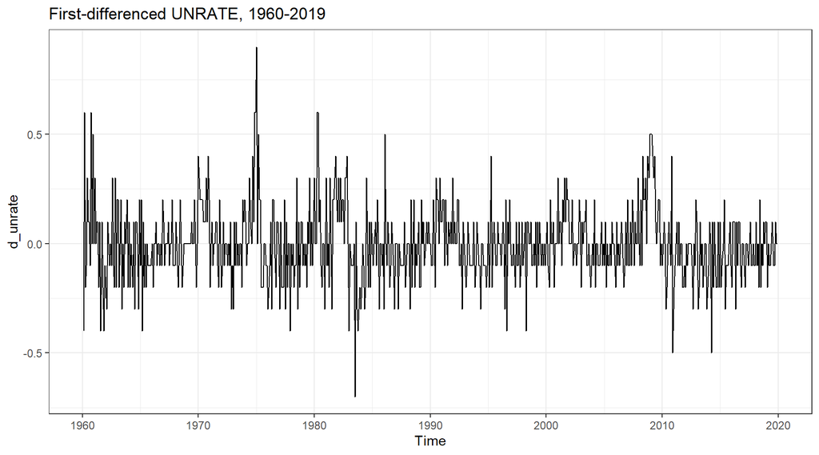

```r
autoplot(d_unrate) +
  ggtitle("First-differenced UNRATE, 1960-2019") + theme_bw()
```

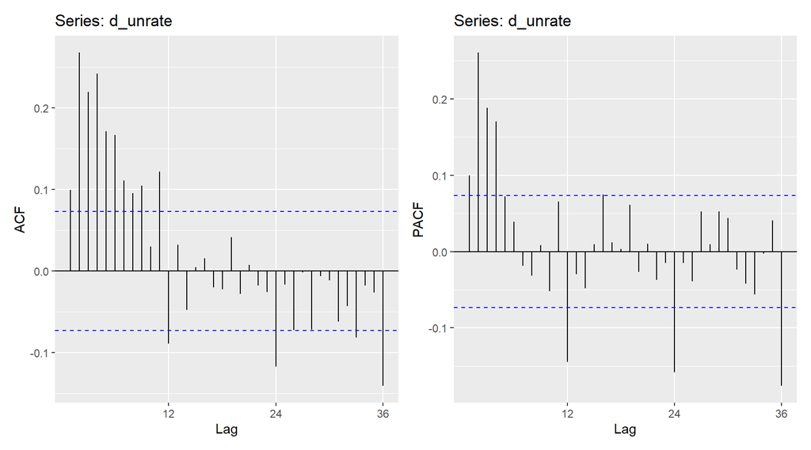

```r
(ggAcf(d_unrate, lag.max = 36) | ggPacf(d_unrate, lag.max = 36))
```

### 4.7.2 An Honest Caveat

Before we proceed, a caveat that is both honest and pedagogically deliberate. The unemployment rate is a monthly series, and the correlograms show bumps at lags 12 and 24 — negative, modest, but visible — which is worth checking for annual seasonality. A seasonal ARIMA is a candidate to compare against, but the ACF by itself is not proof. We are going to proceed with a non-seasonal ARMA today *knowingly*, as a pedagogical exercise, and treat the seasonal ACF bumps as evidence that our model may be incomplete. This is a deliberate teaching choice: we want to run the Box-Jenkins workflow on a real series inside the Module 4 toolkit, and then *discover* that the toolkit is insufficient, which motivates Module 5.

### 4.7.3 Propose Candidates

Reading the ACF/PACF of the differenced series: both tail off. There is positive autocorrelation spread over roughly the first six lags — the largest spikes sit at lags 2 through 4 rather than in a single clean spike at lag 1 — and the PACF shows the same early structure. Neither correlogram has a clean cutoff anywhere. This is the ARMA correlogram trap from Section 4.1, live on real data: the class is “low-order ARMA,” and the orders are anyone’s guess. A defensible candidate list:

- ARMA(1,0) — the simplest persistence story: one AR lag carries the early correlation
- ARMA(0,1) — the simplest shock-memory story: one MA lag
- ARMA(1,1) — both tail off, classic ARMA
- ARMA(2,1) — maybe we need a second AR lag
- ARMA(1,2) — maybe we need a second MA lag
- ARMA(2,2) — the insurance candidate

**Commit to the mean policy before scoring.** For this exercise we impose a zero process mean on monthly changes: $\mathbb{E}[\Delta y_t]=0$. Economically, that says the unemployment rate does not have a permanent deterministic monthly drift over this long window. It also makes the comparison fair: every manual candidate and the non-seasonal automatic search face the same restriction. In R that means `include.mean = FALSE` for `Arima()` and `allowmean = FALSE` for `auto.arima()`. This is a modeling decision, not a theorem; if your application implies a nonzero mean change, rerun **every** candidate with that alternative policy.

### 4.7.4 Estimate and Score

```r
candidates <- list(
  "(1,0,0)" = c(1, 0, 0),
  "(0,0,1)" = c(0, 0, 1),
  "(1,0,1)" = c(1, 0, 1),
  "(2,0,1)" = c(2, 0, 1),
  "(1,0,2)" = c(1, 0, 2),
  "(2,0,2)" = c(2, 0, 2)
)

fits <- lapply(candidates, function(ord) {
  Arima(d_unrate, order = ord, include.mean = FALSE)
})

ic_table <- data.frame(
  model = names(fits),
  AIC   = sapply(fits, AIC),
  AICc  = sapply(fits, function(f) f$aicc),
  BIC   = sapply(fits, BIC)
)
ic_table[order(ic_table$AIC), ]
```

```
          model       AIC      AICc       BIC
(1,0,2) (1,0,2) -549.3327 -549.2767 -531.0212
(2,0,2) (2,0,2) -548.8514 -548.7672 -525.9621
(2,0,1) (2,0,1) -545.2027 -545.1467 -526.8913
(1,0,1) (1,0,1) -517.8257 -517.7921 -504.0921
(1,0,0) (1,0,0) -453.0474 -453.0306 -443.8917
(0,0,1) (0,0,1) -450.6092 -450.5924 -441.4534
```

Under the stated zero-mean policy, all three criteria select ARMA(1,2). ARMA(2,2) sits only 0.48 AIC points behind, but 5.06 BIC points behind: the extra AR lag buys almost enough likelihood to clear AIC’s light hurdle, but not BIC’s heavier one. This is exactly why we committed to the mean restriction before looking at the scoreboard; otherwise an apparent order-selection result could actually be a hidden mean-term comparison.

Compare with `auto.arima()`:

```r
# Non-seasonal (our toolkit today), under the same zero-mean policy
auto.arima(d_unrate, d = 0, seasonal = FALSE,
           allowmean = FALSE, allowdrift = FALSE,
           approximation = FALSE)
```

```
Series: d_unrate
ARIMA(1,0,2) with zero mean

Coefficients:
         ar1      ma1     ma2
      0.8638  -0.8963  0.2319
s.e.  0.0327   0.0473  0.0379

sigma^2 = 0.02707:  log likelihood = 278.67
AIC=-549.33   AICc=-549.28   BIC=-531.02
```

```r
# Seasonal preview on the levels, also excluding deterministic drift
auto.arima(unrate, seasonal = TRUE,
           allowmean = FALSE, allowdrift = FALSE,
           approximation = FALSE)
```

```
Series: unrate
ARIMA(1,1,2)(2,0,1)[12]

Coefficients:
         ar1      ma1     ma2    sar1     sar2     sma1
      0.9057  -0.9369  0.2187  0.4784  -0.0756  -0.7194
s.e.  0.0267   0.0441  0.0396  0.0867   0.0495   0.0794

sigma^2 = 0.02476:  log likelihood = 310.83
AIC=-607.67   AICc=-607.51   BIC=-575.62
```

The non-seasonal call is now comparable to the manual grid on the mean restriction: both model $\Delta y_t$ with zero process mean, and both select ARMA(1,2). The seasonal call on levels selects ARIMA$(1,1,2)(2,0,1)_{12}$ without drift. That is a preview rather than an IC comparison with the differenced table: it is evidence to add seasonal AR/MA candidates to the candidate set, not proof that a seasonal difference is required.

### 4.7.5 Pick a Working Model

Choose — publicly, with reasoning — a working candidate. For the course’s explanation/parsimony goal in this section, use the BIC winner under the zero-mean policy, provided its estimates and roots are sensible. Here that is ARMA(1,2), also selected by AIC, AICc, and the comparable automatic search. Hold it up as a working model, not a verdict: “This is our best guess today. It is not final. Next module we will check whether the residuals look like white noise, and if they do not, seasonality is one of the first things we will inspect.”

### 4.7.6 Preview the Residuals

Show the residual plot and the residual ACF — but do not diagnose them formally. That is Module 5.

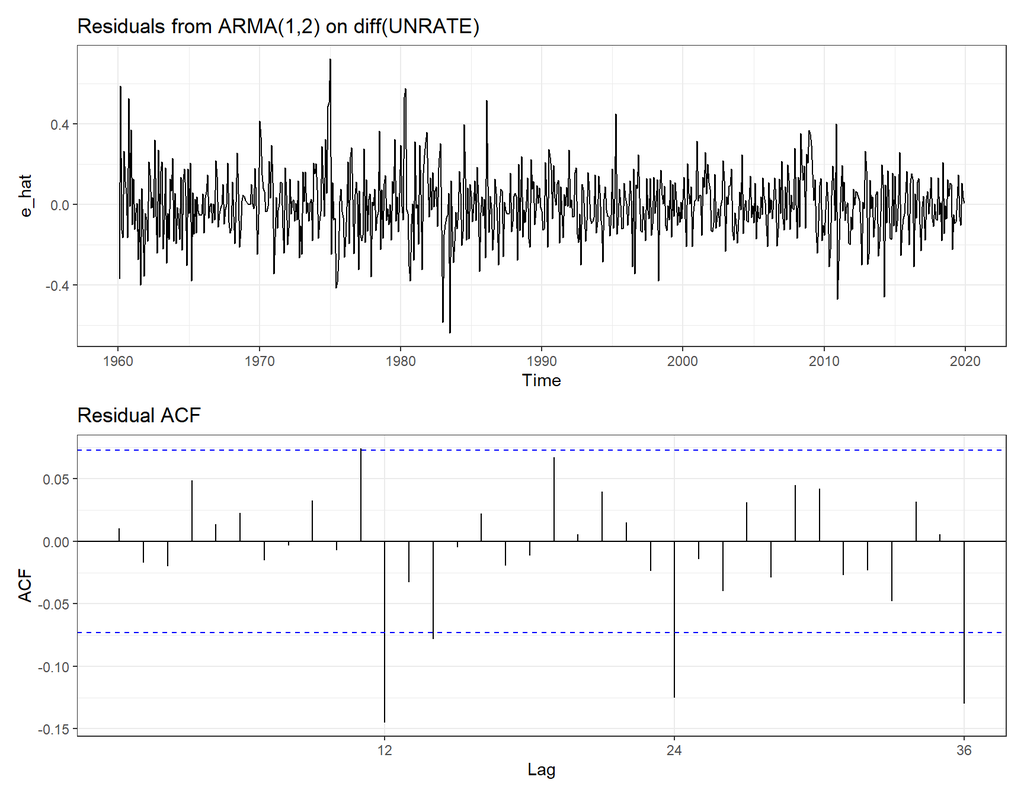

```r
e_hat <- residuals(fits[["(1,0,2)"]])
(autoplot(e_hat) +
   ggtitle("Residuals from ARMA(1,2) on diff(UNRATE)") + theme_bw()) /
  (ggAcf(e_hat, lag.max = 36) + ggtitle("Residual ACF") + theme_bw())
```

Look at the residual ACF. The low lags are quiet — the working ARMA has absorbed the short-run dynamics. But see that negative spike at lag 12, with an echo at lag 24? That is a hint of seasonal structure, not a verdict. Our non-seasonal ARMA may not explain it. That is the cliffhanger for Module 5: residual diagnostics will tell us whether the pattern is material, and seasonal modeling will separate two distinct possibilities — seasonal AR/MA dynamics versus a seasonal unit root. A lag-12 spike alone does **not** justify seasonal differencing; $D=1$ needs unit-root evidence.

## 4.8 What Module 4 Did Not Cover

Three important topics remain open after this module. All of them will be addressed before the midpoint of the course.

1. **Residual diagnostics.** We previewed the residual ACF in Section 4.7.6 but did not interpret it formally. The tools for doing so — the Ljung-Box $Q$ statistic, residual ACF/PACF reading, and the logic of “residuals should be white noise if the model is correct” — are the subject of Module 5.
2. **Seasonality.** The lag-12 spike in the UNRATE residual ACF is a sign that seasonal structure may still be present in our non-seasonal ARMA fit. Module 5 introduces the SARIMA$(p,d,q)(P,D,Q)_s$ specification and separates seasonal AR/MA dynamics from seasonal differencing. The latter is used only when evidence supports a seasonal unit root.
3. **Forecasting.** The Box-Jenkins workflow ends with “forecast using the fitted model.” We have not done that yet. Forecasting methods, out-of-sample evaluation, and forecast comparison are Block 4.

After Module 5, students will be fitting the full (S)ARIMA$(p,d,q)(P,D,Q)_s$ specification end-to-end, with diagnostics to confirm the fit. After Block 4, they will be forecasting with it. The workflow we built in this module — identify, estimate, score, check — is the template for all of that. The only thing that changes is the range of models in the candidate set.

## Common Pitfalls and Misconceptions

1. **“The model with the lowest AIC is the right model.”** No. IC is one line of evidence among several. Residual diagnostics (Module 5) can overturn an IC winner. On real data, “the right model” usually does not exist.
2. **“AIC and BIC always agree.”** They do not. When they disagree, AIC usually picks the larger model and BIC usually picks the smaller one. The disagreement is informative, not a problem.
3. **“BIC is better because its penalty is stronger.”** No. BIC is better for selection consistency under a “true model exists” assumption. AIC is better for forecasting when the true model is not in the set. Different goals, different tools.
4. **“MLE is something different from OLS.”** For pure AR(p), the conditional fit is OLS-like under Gaussian innovations. The exact/default `arima()` fit is still numerical, and MLE becomes genuinely new only once the model has moving-average or ARMA structure.
5. **“`auto.arima()` picks the correct model.”** It picks the model that minimizes its chosen IC over its chosen search path. That is often, but not always, the model a thoughtful analyst would pick. Read its work.
6. **“If I add more parameters, my log-likelihood always goes up, so I should add parameters.”** True that the log-likelihood weakly increases with parameters. That is exactly why the penalty exists. The log-likelihood is the race car; the penalty is the speed limit.
7. **“Log-likelihood is a probability.”** No. Likelihood is a density evaluated at the data, treated as a function of the parameters. It can be greater than 1. What matters is its comparison across parameter values, not its absolute magnitude.
8. **“Conditional and exact MLE must agree once the sample is reasonably large.”** There is no universal sample-size or decimal-place rule. Their gap depends on persistence, proximity to nonstationary or noninvertible boundaries, initial conditions, and the sample itself. The default `method = "CSS-ML"` uses conditional sum of squares for starting values and then performs the ML optimization; use it as the course default, but inspect convergence and sensitivity when the fit is difficult.

## Connection to Enders

- Sample ACF/PACF, tentative ARMA fits, AIC/SBC comparisons: Enders Chapter 2, pp. 72–75
- Box-Jenkins model selection, parsimony, and diagnostic checking: Enders Chapter 2, pp. 76–79
- Forecast evaluation and holdout comparisons: Enders Chapter 2, pp. 82–87
- Exact and conditional Gaussian likelihood for ARMA: Hamilton Chapter 5, especially pp. 125–145

**A convention warning when you cross-reference.** Enders reports the BIC under the name **SBC** (Schwarz Bayesian Criterion) — same formula, different label — and, as in Module 3, writes AR coefficients as $a_i$ where we write $\phi_j$. Hamilton Chapter 5 is the rigorous treatment of exact and conditional maximum likelihood for ARMA models, if you want the derivations we deliberately skipped. Hyndman & Athanasopoulos cover the same selection workflow from the forecasting angle (their Chapter 9), including why `auto.arima()` defaults to AICc and how its stepwise search works.

## Practice Problems

### Core Practice

1. **Conditional AR fit $\approx$ OLS verification.** Fit an AR(1) with `arima(y, order = c(1,0,0), include.mean = FALSE, method = "CSS")` and with a no-intercept `lm()` (after constructing the lagged variable by hand), and verify that the coefficients agree. Write one paragraph explaining why the conditional fit is OLS-like for AR models but not for MA models. Then compare that result with the default ML fit under the **same** zero-mean policy and discuss the observed gap without invoking a fixed decimal-place rule.
2. **Single-realization IC table.** Simulate a zero-mean ARMA(1,1) with $\phi = 0.6$, $\theta = 0.4$, and $T = 500$. Fit all nine candidates in $\{0, 1, 2\} \times \{0, 1, 2\}$ with `include.mean = FALSE`. Report the full IC table (AIC, AICc, BIC). Which model is ranked first by each criterion? Do they agree?
3. **Scaled-down Monte Carlo.** Repeat Problem 2 as a Monte Carlo with 200 replications (a scaled-down version of the in-class assumption-break from Section 4.6). Report AIC and BIC selection frequencies. Write one paragraph on the overfit-vs-underfit pattern: when AIC misses, does it tend to pick larger or smaller models? Same question for BIC.
4. **AICc vs. AIC on a short series.** Take an AR(2) DGP with $\phi_1 = 0.7$, $\phi_2 = 0.2$, and $T = 100$ (a small sample). Run a Monte Carlo with 200 replications, fitting a $\{0, 1, 2, 3\} \times \{0, 1, 2, 3\}$ grid. Compare AIC and AICc selection frequencies. Does AICc do better than AIC at avoiding overfit? How does BIC compare to both?
5. **UNRATE IC table.** For the differenced FRED UNRATE series (1960–2019, as in Section 4.7), fit the six candidates used in class under the stated zero-mean policy and reproduce the IC table. Which candidate would you pick, and why? (Two to three sentences, including whether AIC and BIC agree.) Then refit the grid with a process mean and explain whether the policy changes the ranking.
6. **Build your own grid search.** Without using `auto.arima()`, write a function that takes a time series, maximum $p$ and $q$, and a mean-policy argument; fits the full $(p, q)$ grid with `Arima()`; rejects null fits, non-finite IC values, and optimizer codes other than zero; and returns a ranked IC table with AIC, AICc, and BIC columns. Test it on the simulated ARMA(1,1) from Problem 2 and compare its top-ranked model with `auto.arima()` under the same mean restriction. If they disagree, check the searched order set and stepwise path before deciding which result you believe.

## Key Takeaways

1. **The correlogram trap.** For ARMA(p,q), both the ACF and the PACF tail off, so the identification rules from Module 3 cannot determine the orders $(p, q)$ by themselves. Information criteria fill the gap.
2. **Box-Jenkins is the workflow.** Identification $\rightarrow$ Estimation $\rightarrow$ Diagnostics $\rightarrow$ Forecasting. The rest of the course runs on this template (Box & Jenkins, 1970).
3. **Maximum likelihood** answers “which parameters make the data most likely?” For pure AR(p), the conditional fit is OLS-like on the regression with lagged values. The exact/default `arima()` fit is usually numerical. For MA/ARMA, the optimizer is genuinely doing new work because past innovations are unobserved.
4. **Classical likelihood information criteria**: $\text{IC} = -2 \log L + \text{penalty}$. Three main flavors — AIC ($2k$, Akaike 1974), BIC ($k \log T$, Schwarz 1978), AICc (small-sample correction, Hurvich & Tsai 1989). Smaller is better among models fitted to comparable data and likelihoods.
5. **AIC tends to select larger models; BIC tends to select smaller ones.** Neither is automatically “right.” Report both and use the disagreement as information. Under their respective regularity conditions, AIC has a prediction-efficiency result and BIC has a selection-consistency result; actual forecasts still face rolling-origin evaluation.
6. **`auto.arima()` is a very good intern** — read its work, override it when you have reasons, and always confirm with diagnostics.
7. **IC is not an oracle.** The Monte Carlo showed that even with the true model in the candidate set and $T = 500$, AIC missed it about a quarter of the time (and BIC about one in ten) — and both do worse in shorter samples. IC is one line of evidence among several.
8. **Sign conventions, one more time.** $\Phi(L) = 1 - \sum \phi_j L^j$ (minus), $\Theta(L) = 1 + \sum \theta_l L^l$ (plus). $\epsilon_t$ for DGP innovations, $e_t$ for residuals of an estimated model. When in doubt, consult notation_dictionary.md.

## Looking Ahead — Module 5

Module 4 hands Module 5 a **fitted but unchecked model** selected under an explicit mean policy. Its residual ACF is already whispering that something may be missing at lag 12. Module 5 tests that whisper rather than treating it as a verdict:

- **Residual diagnostics.** The Ljung-Box $Q$ test and residual correlogram reading make “do the residuals look like white noise?” a testable question rather than an eyeball call. If your model is right, $e_t$ should behave like $\epsilon_t$ — that is the payoff of the notation distinction we have carried since Module 1.
- **Seasonality and SARIMA.** The lag-12 spike motivates seasonal AR/MA candidates. Seasonal differencing is a separate decision and requires evidence of a seasonal unit root. The $(p,d,q)(P,D,Q)_s$ notation is the last block of sliders on the mixing board.

After that, the Box-Jenkins loop is complete — identify, estimate, score, *check* — and Block 4 puts the surviving model to work forecasting.